# Lab 4

Cody Nielsen

10/11/2020

## Loading Data

```r
library(tidyverse)
library(readxl)

defense <- read_excel("cyclonesFootball2019.xlsx", sheet= 'Defensive')
str(defense)
```

```
## tibble [502 x 11] (S3: tbl_df/tbl/data.frame)
##  $ Name             : chr [1:502] "White, Lawrence" "White, Lawrence" "White, Lawrence" "White, Lawrence" ...
##  $ Opponent_Opponent: chr [1:502] "UNI" "Iowa" "ULM" "Baylor" ...
##  $ Tackles_Solo     : chr [1:502] "4" "4" "3" "4" ...
##  $ Tackles_ASST     : chr [1:502] "4" "7" "5" "2" ...
##  $ Tackles_TFL      : chr [1:502] "0" "0" "0" "0" ...
##  $ Tackles_Sack     : chr [1:502] "0" "0" "0" "0" ...
##  $ Turnover_FF      : chr [1:502] "0" "0" "0" "0" ...
##  $ Turnover_FR      : chr [1:502] "0" "0" "0" "0" ...
##  $ Turnover_INT     : chr [1:502] "0" "0" "1" "0" ...
##  $ Pass_QBH         : chr [1:502] "1" "0" "0" "0" ...
##  $ Pass_PB          : chr [1:502] "1" "2" "0" "0" ...
```

```r
offense <- read_excel('cyclonesFootball2019.xlsx', sheet= 'Offensive')
str(offense)
```

```
## tibble [195 x 12] (S3: tbl_df/tbl/data.frame)
##  $ Name             : chr [1:195] "Akers, Landen" "Akers, Landen" "Akers, Landen" "Akers, Landen" ...
##  $ Opponent_Opponent: chr [1:195] "UNI" "Iowa" "ULM" "Baylor" ...
##  $ Rushing_ATT      : chr [1:195] "0" "0" "1" "0" ...
##  $ Rushing_YDS      : chr [1:195] "0" "0" "8" "0" ...
##  $ Rushing_TD       : chr [1:195] "0" "0" "0" "0" ...
##  $ Receiving_REC    : chr [1:195] "1" "0" "0" "0" ...
##  $ Receiving_YDS    : chr [1:195] "21" "0" "0" "0" ...
##  $ Receiving_TD     : chr [1:195] "0" "0" "0" "0" ...
##  $ Passing_CMP-ATT  : chr [1:195] NA NA NA NA ...
##  $ Passing_YDS      : chr [1:195] NA NA NA NA ...
##  $ Passing_TD       : chr [1:195] NA NA NA NA ...
##  $ Passing_INT      : chr [1:195] NA NA NA NA ...
```

```r
biography <- read_excel('cyclonesFootball2019.xlsx', sheet= 'Biography')
str(biography)
```

```
## tibble [105 x 7] (S3: tbl_df/tbl/data.frame)
##  $ Name      : chr [1:105] "Akers, Landen" "Allen, Chase" "Anderson, Ezeriah" "Assalley, Connor" ...
##  $ Position  : chr [1:105] "Wide Receiver" "Tight End" "Wide Receiver" "Placekicker" ...
##  $ Height    : chr [1:105] "6-0" "6-7" "6-5" "6-0" ...
##  $ Weight    : chr [1:105] "188" "245" "204" "195" ...
##  $ Class     : chr [1:105] "Redshirt Senior" "Redshirt Senior" "Redshirt Freshman" "Redshirt Senior" ...
##  $ Hometown  : chr [1:105] "Cedar Rapids, Iowa" "Nixa, Mo." "Seffner, Fla." "Naperville, Ill." ...
##  $ Highschool: chr [1:105] "Washington" "Nixa" "Armwood" "Central" ...
```

##Part one: Cleaning data

1.The player names and opponent names are factors.

```r
library(tidyverse)

defense$Name <- as.factor(defense$Name)
defense$Opponent_Opponent <- as.factor(defense$Opponent_Opponent)
offense$Name <- as.factor(offense$Name)
offense$Opponent_Opponent <- as.factor(offense$Opponent_Opponent)
biography$Name <- as.factor(biography$Name)
```

2. All offensive and defensive statistics are numerical. The Weight column in biogrpahy is also numeric.Change the Height column in biogrpahy into numeric.

```r
defClean <- defense %>% mutate_at(c("Tackles_Solo","Tackles_ASST", "Tackles_TFL","Tackles_Sack","Turnover_FF","Turnover_FR","Turnover_INT","Pass_QBH","Pass_PB"),as.numeric)

offClean <- offense %>% replace_na(list(.=0)) %>% mutate_if(is.character,list(~replace_na(.,0))) %>% mutate_at(c("Rushing_ATT","Rushing_YDS", "Rushing_TD","Receiving_REC","Receiving_YDS","Receiving_TD","Passing_YDS","Receiving_TD","Passing_CMP-ATT","Passing_YDS","Passing_TD","Passing_INT"),as.numeric)
```

```r
bioClean <- biography %>% separate(col = Height,into = c("Feet", "Inches"), sep = "-") %>% mutate(Weight = as.numeric(Weight)) %>% mutate(Feet = as.numeric(Feet),Inches = as.numeric(Inches)) %>% mutate(Height = Feet * 12 + Inches) %>% select (-Feet , -Inches)

str(defClean)
```

```
## tibble [502 x 11] (S3: tbl_df/tbl/data.frame)
##  $ Name             : Factor w/ 43 levels "Akers, Landen",..: 40 40 40 40 40 40 40 40 40 40 ...
##  $ Opponent_Opponent: Factor w/ 13 levels "Baylor","Iowa",..: 12 2 11 1 8 13 10 7 6 9 ...
##  $ Tackles_Solo     : num [1:502] 4 4 3 4 3 1 7 3 6 5 ...
##  $ Tackles_ASST     : num [1:502] 4 7 5 2 2 1 1 2 1 5 ...
##  $ Tackles_TFL      : num [1:502] 0 0 0 0 1 0 0 0 1 1 ...
##  $ Tackles_Sack     : num [1:502] 0 0 0 0 0 0 0 0 0 1 ...
##  $ Turnover_FF      : num [1:502] 0 0 0 0 0 0 0 0 0 0 ...
##  $ Turnover_FR      : num [1:502] 0 0 0 0 0 0 0 0 0 0 ...
##  $ Turnover_INT     : num [1:502] 0 0 1 0 0 0 0 0 1 0 ...
##  $ Pass_QBH         : num [1:502] 1 0 0 0 0 0 0 0 1 0 ...
##  $ Pass_PB          : num [1:502] 1 2 0 0 0 1 0 0 0 0 ...
```

```r
str(offClean)
```

```
## tibble [195 x 12] (S3: tbl_df/tbl/data.frame)
##  $ Name             : Factor w/ 17 levels "Akers, Landen",..: 1 1 1 1 1 1 1 1 1 1 ...
##  $ Opponent_Opponent: Factor w/ 13 levels "Baylor","Iowa",..: 12 2 11 1 8 13 10 7 6 9 ...
##  $ Rushing_ATT      : num [1:195] 0 0 1 0 0 0 0 0 0 0 ...
##  $ Rushing_YDS      : num [1:195] 0 0 8 0 0 0 0 0 0 0 ...
##  $ Rushing_TD       : num [1:195] 0 0 0 0 0 0 0 0 0 0 ...
##  $ Receiving_REC    : num [1:195] 1 0 0 0 1 0 0 4 0 1 ...
##  $ Receiving_YDS    : num [1:195] 21 0 0 0 32 0 0 39 0 7 ...
##  $ Receiving_TD     : num [1:195] 0 0 0 0 0 0 0 0 0 0 ...
##  $ Passing_CMP-ATT  : num [1:195] 0 0 0 0 0 0 0 0 0 0 ...
##  $ Passing_YDS      : num [1:195] 0 0 0 0 0 0 0 0 0 0 ...
##  $ Passing_TD       : num [1:195] 0 0 0 0 0 0 0 0 0 0 ...
##  $ Passing_INT      : num [1:195] 0 0 0 0 0 0 0 0 0 0 ...
```

```r
str(bioClean)
```

```
## tibble [105 x 7] (S3: tbl_df/tbl/data.frame)
##  $ Name      : Factor w/ 105 levels "Akers, Landen",..: 1 2 3 4 5 6 7 8 9 10 ...
##  $ Position  : chr [1:105] "Wide Receiver" "Tight End" "Wide Receiver" "Placekicker" ...
##  $ Weight    : num [1:105] 188 245 204 195 190 235 255 285 300 215 ...
##  $ Class     : chr [1:105] "Redshirt Senior" "Redshirt Senior" "Redshirt Freshman" "Redshirt Senior" ...
##  $ Hometown  : chr [1:105] "Cedar Rapids, Iowa" "Nixa, Mo." "Seffner, Fla." "Naperville, Ill." ...
##  $ Highschool: chr [1:105] "Washington" "Nixa" "Armwood" "Central" ...
##  $ Height    : num [1:105] 72 79 77 72 72 75 74 74 72 78 ...
```

#Part two: Tidying

1.Reformat the defClean data frame into a tidy format using pivot_longer. The type of statistic (Tackles_Solo, Tackles_ASST, etc) is added as a new key column named stat.

```r
defClean2 <- defClean %>% pivot_longer(Tackles_Solo:Pass_PB, names_to = 'stat', values_to = 'count')

head(defClean2)
```

```
## # A tibble: 6 x 4
##   Name            Opponent_Opponent stat         count
##   <fct>           <fct>             <chr>        <dbl>
## 1 White, Lawrence UNI               Tackles_Solo     4
## 2 White, Lawrence UNI               Tackles_ASST     4
## 3 White, Lawrence UNI               Tackles_TFL      0
## 4 White, Lawrence UNI               Tackles_Sack     0
## 5 White, Lawrence UNI               Turnover_FF      0
## 6 White, Lawrence UNI               Turnover_FR      0
```

2.Compare the distributions of the defensive statistics. What defensive skills are rare?

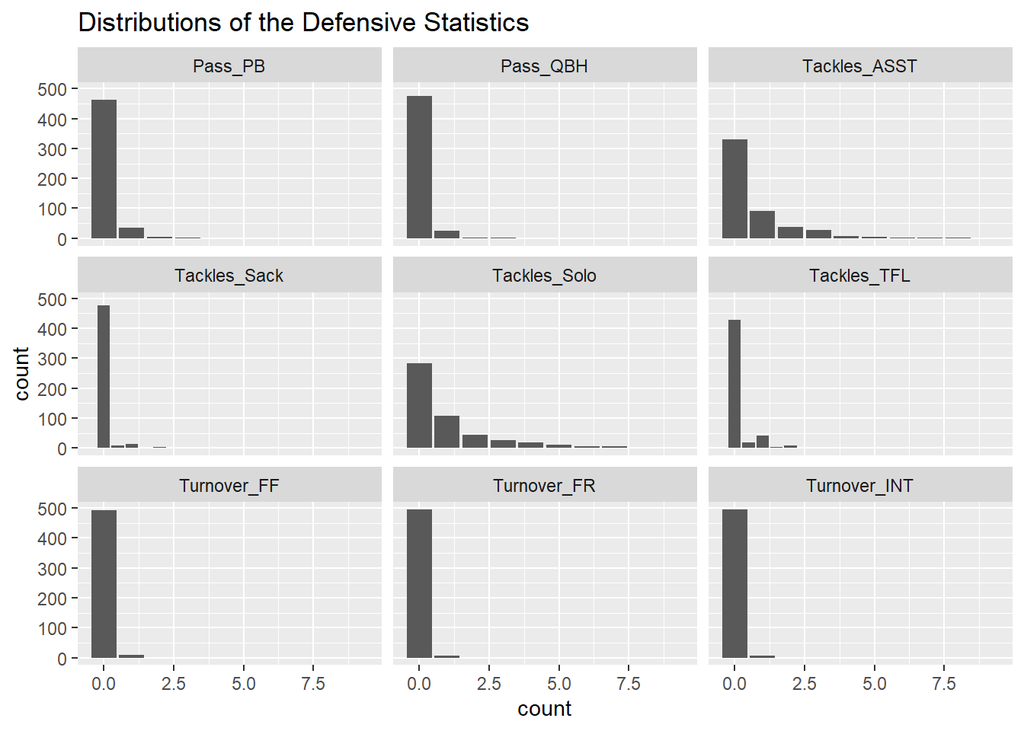

```r
ggplot(defClean2, aes(x = count)) + geom_bar() + facet_wrap(~stat) + labs(title = "Distributions of the Defensive Statistics")
```

Turnovers are rare defensive skills with high count value of 0.Tackles for loss and sacks also appear to be rare.

3.Did ISU have better defense against Iowa or Notre Dame? Answer this question by creating a scatterplot with x- and y-axes being the number of solo tackles (of each player). A large number of solo tackles is an indicator of good defense.

[figure not shown]

```r
betterDef <- defClean2 %>% pivot_wider(names_from = Opponent_Opponent, values_from = count) %>% filter(stat == 'Tackles_Solo') %>% select(c('Iowa' ,'Notre Dame', stat))

ggplot(betterDef, aes(x = Iowa, 'Notre Dame')) + geom_point(position = 'jitter') + labs(x = 'Defense againts Iowa', y = 'Defense against Notre Dame', title = 'ISU defense against Iowa vs Notre Dame by solo tackles')
```

4. Separate the Hometown column into two columns, namely the city and the state. Print the first few rows of these two columns. (Hint: look at the sep= argument of separate)

```r
bioClean1 <- bioClean %>% separate(Hometown, c('city', 'state'), sep = ',')

head(bioClean1)
```

```
## # A tibble: 6 x 8
##   Name         Position    Weight Class       city      state  Highschool Height
##   <fct>        <chr>        <dbl> <chr>       <chr>     <chr>  <chr>       <dbl>
## 1 Akers, Land~ Wide Recei~    188 Redshirt S~ Cedar Ra~ " Iow~ Washington     72
## 2 Allen, Chase Tight End      245 Redshirt S~ Nixa      " Mo." Nixa           79
## 3 Anderson, E~ Wide Recei~    204 Redshirt F~ Seffner   " Fla~ Armwood        77
## 4 Assalley, C~ Placekicker    195 Redshirt S~ Napervil~ " Ill~ Central        72
## 5 Azunna, Arn~ Defensive ~    190 Redshirt S~ Grand Pr~ " Tex~ Lake Ridge     72
## 6 Bailey, Cor~ Defensive ~    235 Redshirt J~ Clarksda~ " Mis~ Clarksdale     75
```

5. How many players are there from each state?

```r
bioClean2 <- bioClean1 %>% group_by(state) %>% summarize(number_players = n()) %>% arrange(desc(number_players))
table(bioClean2)
```

```
##             number_players
## state        1 2 3 4 5 6 7 10 35
##    Ariz.     0 0 0 1 0 0 0  0  0
##    Ark.      1 0 0 0 0 0 0  0  0
##    Australia 1 0 0 0 0 0 0  0  0
##    Calif.    0 0 1 0 0 0 0  0  0
##    Fla.      0 0 0 0 0 0 0  1  0
##    Ga.       0 0 0 1 0 0 0  0  0
##    Ill.      0 0 0 0 1 0 0  0  0
##    Iowa      0 0 0 0 0 0 0  0  1
##    Kan.      0 0 1 0 0 0 0  0  0
##    Mich.     0 0 0 1 0 0 0  0  0
##    Minn.     0 0 0 1 0 0 0  0  0
##    Miss.     1 0 0 0 0 0 0  0  0
##    Mo.       0 0 0 0 0 1 0  0  0
##    Ohio      0 0 0 0 0 0 1  0  0
##    Okla.     0 1 0 0 0 0 0  0  0
##    Pa.       1 0 0 0 0 0 0  0  0
##    S.D.      0 1 0 0 0 0 0  0  0
##    Texas     0 0 0 0 0 1 0  0  0
##    Wis.      0 0 0 0 0 1 0  0  0
```

35 Players are from Iowa. 10 players are from Florida. 7 players are from Ohio. There is 1 player from Australia which is a country.

##Part three: Joining data frames

1. Find which states do the ISU defensive and offensive players come from. Create an appropriate summary.

```r
defHome <- defClean %>% left_join(bioClean1, by = 'Name') %>% select(Name, state) %>% distinct()


table(defHome)
```

```
##                         state
## Name                      Ark.  Calif.  Fla.  Ga.  Iowa  Kan.  Mich.  Mo.  Ohio
##   Akers, Landen              0       0     0    0     1     0      0    0     0
##   Allen, Chase               0       0     0    0     0     0      0    1     0
##   Azunna, Arnold             0       0     0    0     0     0      0    0     0
##   Bailey, JaQuan             0       0     1    0     0     0      0    0     0
##   Bickham, Justin            0       0     0    0     0     0      0    0     0
##   Downing, Trevor            0       0     0    0     1     0      0    0     0
##   Eisworth, Greg             0       0     0    0     0     0      0    0     0
##   Gescheidler, Jared         0       0     0    0     0     0      0    0     0
##   Grant, Jatairis            0       0     0    0     0     0      0    0     1
##   Greene, Conner             0       0     0    0     0     0      0    0     0
##   Hall, Breece               0       0     0    0     0     1      0    0     0
##   Hummel, Jake               0       0     0    0     1     0      0    0     0
##   Johnson , Anthony          0       0     1    0     0     0      0    0     0
##   Johnson, Jamahl            0       0     0    0     0     0      0    0     0
##   Jones, Keontae             0       0     0    0     0     0      0    0     1
##   King, Kym-Mani             0       0     1    0     0     0      0    0     0
##   Kolar, Charlie             0       0     0    0     0     0      0    0     0
##   Kyle, Tayvonn              0       0     0    1     0     0      0    0     0
##   Leo, Matt                  0       0     0    0     0     0      0    0     0
##   Lewis, Braxton             0       0     0    0     0     0      0    0     0
##   Lima, Ray                  0       0     0    0     0     0      0    0     0
##   McDonald, Will             0       0     0    0     0     0      0    0     0
##   Miller, D.J.               0       0     0    0     0     0      0    1     0
##   Paddock, Peyton            0       0     0    0     0     0      0    0     0
##   Petersen, Zach             0       0     0    0     1     0      0    0     0
##   Pettway, La'Michael        0       0     0    0     0     0      0    0     0
##   Pulvermacher, Chandler     0       0     0    0     0     0      0    0     0
##   Robertson, Tucker          0       1     0    0     0     0      0    0     0
##   Rose, Mike                 0       0     0    0     0     0      0    0     1
##   Rus, Jared                 0       0     0    0     1     0      0    0     0
##   Shaw Jr., Sean             0       0     0    0     0     0      0    0     0
##   Soehner, Dylan             1       0     0    0     0     0      0    0     0
##   Spears, Tory               0       0     0    0     0     0      0    0     0
##   Sutton, Tymar              0       0     0    0     0     0      0    0     0
##   Uwazurike, Eyioma          0       0     0    0     0     0      1    0     0
##   Vance, O'Rien              0       0     0    0     1     0      0    0     0
##   Vaughn, Gerry              0       0     0    1     0     0      0    0     0
##   Walker, Amechie            0       0     0    0     0     0      0    0     0
```

[output cut: 185 more lines]

```
##   Rivera, Joe                 0      0     0
##   Rodgers, Tyler              0      0     0
##   Ross, Zach                  0      0     0
##   Scates, Joe                 0      0     0
##   Schweiger, Derek            0      0     0
##   Seres, Matt                 0      0     0
##   Sichterman, Dan             0      0     0
##   Simmons, Darrell            0      0     0
##   Skovgard, Mason             0      0     0
##   Starcevich, Shane           0      0     0
##   Suttle, Corey               0      0     0
##   Terwilliger, Owen           0      0     0
##   Treiber, Grant              0      0     0
##   Wilson, Johnny              0      0     0
##   Young, Isheem               0      0     0
```

7 defensive players are from Iowa, which looks to be the majority.

```r
offHome <- offClean %>% left_join(bioClean1, by = 'Name') %>% select(Name, state) %>% distinct()


table(offHome)
```

```
##                         state
## Name                      Ariz.  Ark.  Fla.  Ga.  Ill.  Iowa  Kan.  Mo.  Ohio
##   Akers, Landen               0     0     0    0     0     1     0    0     0
##   Allen, Chase                0     0     0    0     0     0     0    1     0
##   Brock, Jirehl               0     0     0    0     1     0     0    0     0
##   Croney Jr., Sheldon         0     0     0    0     0     0     0    0     0
##   Hall, Breece                0     0     0    0     0     0     1    0     0
##   Jones, Deshaunte            0     0     0    0     0     0     0    0     0
##   Kolar, Charlie              0     0     0    0     0     0     0    0     0
##   Lang, Johnnie               0     0     1    0     0     0     0    0     0
##   Milton, Tarique             0     0     1    0     0     0     0    0     0
##   Mitchell, Re-al             0     0     0    0     0     0     0    0     0
##   Nwangwu, Kene               0     0     0    0     0     0     0    0     0
##   Pettway, La'Michael         0     0     0    0     0     0     0    0     0
##   Purdy, Brock                1     0     0    0     0     0     0    0     0
##   Scates, Joe                 0     0     0    0     0     0     0    0     1
##   Shaw Jr., Sean              0     0     0    0     0     0     0    0     0
##   Soehner, Dylan              0     1     0    0     0     0     0    0     0
##   Wilson, Darren              0     0     0    1     0     0     0    0     0
##   Anderson, Ezeriah           0     0     0    0     0     0     0    0     0
##   Assalley, Connor            0     0     0    0     0     0     0    0     0
##   Azunna, Arnold              0     0     0    0     0     0     0    0     0
##   Bailey, Cordarrius          0     0     0    0     0     0     0    0     0
##   Bailey, JaQuan              0     0     0    0     0     0     0    0     0
##   Bailey, Joshua              0     0     0    0     0     0     0    0     0
##   Bankston, Latrell           0     0     0    0     0     0     0    0     0
##   Bouman, Aidan               0     0     0    0     0     0     0    0     0
##   Bowens III, Richard         0     0     0    0     0     0     0    0     0
##   Cassady, Mason              0     0     0    0     0     0     0    0     0
##   Chambers, Mason             0     0     0    0     0     0     0    0     0
##   Clapper, Will               0     0     0    0     0     0     0    0     0
##   Clark, Blake                0     0     0    0     0     0     0    0     0
##   Coberley, Beau              0     0     0    0     0     0     0    0     0
##   Davis, Dae'Shawn            0     0     0    0     0     0     0    0     0
##   Dean, Easton                0     0     0    0     0     0     0    0     0
##   Downing, Trevor             0     0     0    0     0     0     0    0     0
##   Dunkleberger, Benjamin      0     0     0    0     0     0     0    0     0
##   Dunn, Corey                 0     0     0    0     0     0     0    0     0
##   Edwards II, Virdel          0     0     0    0     0     0     0    0     0
##   Eisworth, Greg              0     0     0    0     0     0     0    0     0
```

[output cut: 167 more lines]

```
##   Sichterman, Dan             0      0
##   Simmons, Darrell            0      0
##   Skovgard, Mason             0      0
##   Starcevich, Shane           0      0
##   Suttle, Corey               0      0
##   Terwilliger, Owen           0      0
##   Treiber, Grant              0      0
##   Uwazurike, Eyioma           0      0
##   Vance, O'Rien               0      0
##   Vaughn, Gerry               0      0
##   Walling, Rory               0      0
##   White, Lawrence             0      0
##   Wilson, Johnny              0      0
##   Young, Datrone              0      0
##   Young, Isheem               0      0
```

There are 2 players from Oklahoma and Florida each and 1 player each for the different states.

2.How does the performance of quarterback Brock Purdy relate to the performance of the ISU team?

```r
isuPerf <- offClean %>% group_by(Opponent_Opponent) %>%
  summarize(rush_yds = sum(Rushing_YDS,na.rm=TRUE),rush_td = sum(Rushing_TD,na.rm=TRUE))
purdyPerf2 <- offClean %>%
  filter(Name=="Purdy, Brock") %>%
  select(Opponent_Opponent,Passing_YDS)

teamPerf <- isuPerf %>%
  left_join(purdyPerf2,by="Opponent_Opponent")

head(teamPerf)
```

```
## # A tibble: 6 x 4
##   Opponent_Opponent rush_yds rush_td Passing_YDS
##   <fct>                <dbl>   <dbl>       <dbl>
## 1 Baylor                  63       1         342
## 2 Iowa                    91       0         276
## 3 Kansas                 118       2         372
## 4 Kansas State            56       1         185
## 5 Notre Dame              45       0         222
## 6 Oklahoma               197       1         282
```

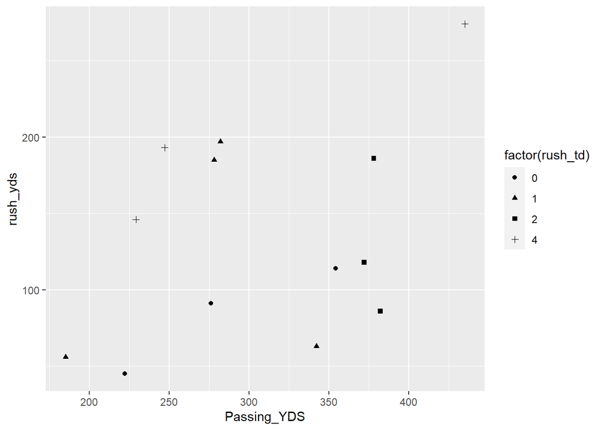

```r
ggplot(teamPerf, aes(x = Passing_YDS, rush_yds, shape = factor(rush_td))) + geom_point(na.rm=TRUE)
```

We can observe Brock Purdys’ performance by looking at the passing yards and ISU’s performance by looking at rush yards. Brock Purdys’ higher passing yards matches ISU’s rush yards.

3.Which ISU player(s) made big progress over the last year? Compare the 2019 and the 2018 data here.

#Load 2018 data

```r
defense18 <- read_excel("cyclonesFootball2018.xlsx", sheet= 'Defensive')
str(defense18)
```

```
## tibble [446 x 11] (S3: tbl_df/tbl/data.frame)
##  $ Name             : chr [1:446] "Eisworth, Greg" "Eisworth, Greg" "Eisworth, Greg" "Eisworth, Greg" ...
##  $ Opponent_Opponent: chr [1:446] "Iowa" "Oklahoma" "Akron" "TCU" ...
##  $ Tackles_Solo     : chr [1:446] "3" "6" "7" "6" ...
##  $ Tackles_ASST     : chr [1:446] "3" "8" "2" "3" ...
##  $ Tackles_TFL      : chr [1:446] "0" "1.0" "1.0" "0" ...
##  $ Tackles_Sack     : chr [1:446] "0" "0" "0" "0" ...
##  $ Turnover_FF      : chr [1:446] "0" "1" "0" "0" ...
##  $ Turnover_FR      : chr [1:446] "0" "0" "0" "0" ...
##  $ Turnover_INT     : chr [1:446] "0" "0" "0" "0" ...
##  $ Pass_QBH         : chr [1:446] "0" "0" "0" "0" ...
##  $ Pass_PB          : chr [1:446] "0" "0" "3" "0" ...
```

```r
offense18 <- read_excel('cyclonesFootball2018.xlsx', sheet= 'Offensive')
str(offense18)
```

```
## tibble [168 x 12] (S3: tbl_df/tbl/data.frame)
##  $ Name             : chr [1:168] "Jones, Deshaunte" "Jones, Deshaunte" "Jones, Deshaunte" "Jones, Deshaunte" ...
##  $ Opponent_Opponent: chr [1:168] "Iowa" "Oklahoma" "Akron" "TCU" ...
##  $ Receiving_REC    : chr [1:168] "1" "9" "6" "3" ...
##  $ Receiving_YDS    : chr [1:168] "31" "66" "39" "23" ...
##  $ Receiving_TD     : chr [1:168] "0" "0" "0" "0" ...
##  $ Rushing_ATT      : chr [1:168] NA NA NA NA ...
##  $ Rushing_YDS      : chr [1:168] NA NA NA NA ...
##  $ Rushing_TD       : chr [1:168] NA NA NA NA ...
##  $ Passing_CMP-ATT  : chr [1:168] NA NA NA NA ...
##  $ Passing_YDS      : chr [1:168] NA NA NA NA ...
##  $ Passing_TD       : chr [1:168] NA NA NA NA ...
##  $ Passing_INT      : chr [1:168] NA NA NA NA ...
```

```r
biography18 <- read_excel('cyclonesFootball2018.xlsx', sheet= 'Biography')
str(biography18)
```

```
## tibble [123 x 7] (S3: tbl_df/tbl/data.frame)
##  $ Name      : chr [1:123] "Akers, Landen" "Allen, Chase" "Alt, Gerry" "Anderson, Cole" ...
##  $ Position  : chr [1:123] "Wide Receiver" "Tight End" "Offensive Line" "Tight End" ...
##  $ Height    : chr [1:123] "6-0" "6-7" "6-2" "6-4" ...
##  $ Weight    : chr [1:123] "192" "240" "290" "250" ...
##  $ Class     : chr [1:123] "Redshirt Sophomore" "Redshirt Sophomore" "Redshirt Freshman" "Redshirt Senior" ...
##  $ Hometown  : chr [1:123] "Cedar Rapids, Iowa" "Nixa, Mo." "Cedar Rapids, Iowa" "League City, Texas" ...
##  $ Highschool: chr [1:123] "Washington" "Nixa" "Washington" "Clear Falls" ...
```

#Clean data

```r
defense18$Name <- as.factor(defense18$Name)
defense18$Opponent_Opponent <- as.factor(defense18$Opponent_Opponent)
offense18$Name <- as.factor(offense18$Name)
offense18$Opponent_Opponent <- as.factor(offense18$Opponent_Opponent)
biography18$Name <- as.factor(biography18$Name)
```

```r
defClean18 <- defense18 %>% mutate_at(c("Tackles_Solo","Tackles_ASST", "Tackles_TFL","Tackles_Sack","Turnover_FF","Turnover_FR","Turnover_INT","Pass_QBH","Pass_PB"),as.numeric)

offClean18 <- offense18 %>% replace_na(list(.=0)) %>% mutate_if(is.character,list(~replace_na(.,0))) %>% mutate_at(c("Rushing_ATT","Rushing_YDS", "Rushing_TD","Receiving_REC","Receiving_YDS","Receiving_TD","Passing_YDS","Receiving_TD","Passing_CMP-ATT","Passing_YDS","Passing_TD","Passing_INT"),as.numeric)
```

```r
bioClean18 <- biography18 %>% separate(col = Height,into = c("Feet", "Inches"), sep = "-") %>% mutate(Weight = as.numeric(Weight)) %>% mutate(Feet = as.numeric(Feet),Inches = as.numeric(Inches)) %>% mutate(Height = Feet * 12 + Inches) %>% select (-Feet , -Inches)

str(defClean18)
```

```
## tibble [446 x 11] (S3: tbl_df/tbl/data.frame)
##  $ Name             : Factor w/ 42 levels "Akers, Landen",..: 7 7 7 7 7 7 7 7 7 7 ...
##  $ Opponent_Opponent: Factor w/ 13 levels "Akron","Baylor",..: 4 7 1 9 8 13 11 5 2 10 ...
##  $ Tackles_Solo     : num [1:446] 3 6 7 6 3 5 3 7 2 9 ...
##  $ Tackles_ASST     : num [1:446] 3 8 2 3 0 3 2 1 4 3 ...
##  $ Tackles_TFL      : num [1:446] 0 1 1 0 1 1 0 0 0 0 ...
##  $ Tackles_Sack     : num [1:446] 0 0 0 0 0 1 0 0 0 0 ...
##  $ Turnover_FF      : num [1:446] 0 1 0 0 0 0 0 0 0 1 ...
##  $ Turnover_FR      : num [1:446] 0 0 0 0 0 0 0 0 0 0 ...
##  $ Turnover_INT     : num [1:446] 0 0 0 0 0 0 1 0 0 0 ...
##  $ Pass_QBH         : num [1:446] 0 0 0 0 0 0 0 0 0 0 ...
##  $ Pass_PB          : num [1:446] 0 0 3 0 0 0 0 0 0 0 ...
```

```r
str(offClean18)
```

```
## tibble [168 x 12] (S3: tbl_df/tbl/data.frame)
##  $ Name             : Factor w/ 15 levels "Akers, Landen",..: 6 6 6 6 6 6 6 6 6 6 ...
##  $ Opponent_Opponent: Factor w/ 13 levels "Akron","Baylor",..: 4 7 1 9 8 13 11 5 2 10 ...
##  $ Receiving_REC    : num [1:168] 1 9 6 3 6 1 1 4 4 0 ...
##  $ Receiving_YDS    : num [1:168] 31 66 39 23 37 32 4 31 39 0 ...
##  $ Receiving_TD     : num [1:168] 0 0 0 0 1 1 0 0 1 0 ...
##  $ Rushing_ATT      : num [1:168] 0 0 0 0 0 0 0 0 0 0 ...
##  $ Rushing_YDS      : num [1:168] 0 0 0 0 0 0 0 0 0 0 ...
##  $ Rushing_TD       : num [1:168] 0 0 0 0 0 0 0 0 0 0 ...
##  $ Passing_CMP-ATT  : num [1:168] 0 0 0 0 0 0 0 0 0 0 ...
##  $ Passing_YDS      : num [1:168] 0 0 0 0 0 0 0 0 0 0 ...
##  $ Passing_TD       : num [1:168] 0 0 0 0 0 0 0 0 0 0 ...
##  $ Passing_INT      : num [1:168] 0 0 0 0 0 0 0 0 0 0 ...
```

```r
str(bioClean18)
```

```
## tibble [123 x 7] (S3: tbl_df/tbl/data.frame)
##  $ Name      : Factor w/ 123 levels "Akers, Landen",..: 1 2 3 4 5 6 7 8 9 10 ...
##  $ Position  : chr [1:123] "Wide Receiver" "Tight End" "Offensive Line" "Tight End" ...
##  $ Weight    : num [1:123] 192 240 290 250 191 205 192 224 251 284 ...
##  $ Class     : chr [1:123] "Redshirt Sophomore" "Redshirt Sophomore" "Redshirt Freshman" "Redshirt Senior" ...
##  $ Hometown  : chr [1:123] "Cedar Rapids, Iowa" "Nixa, Mo." "Cedar Rapids, Iowa" "League City, Texas" ...
##  $ Highschool: chr [1:123] "Washington" "Nixa" "Washington" "Clear Falls" ...
##  $ Height    : num [1:123] 72 79 74 76 72 71 72 75 74 74 ...
```

#Analyze player progress between 2018 and 2019

```r
defComb <- inner_join(defClean, defClean18, by ='Name') %>% mutate(Diff_Tackles_Solo = Tackles_Solo.x - Tackles_Solo.y) %>% select(Name, Diff_Tackles_Solo) %>% arrange(desc(Diff_Tackles_Solo))


defComb
```

```
## # A tibble: 3,264 x 2
##    Name              Diff_Tackles_Solo
##    <fct>                         <dbl>
##  1 Lewis, Braxton                    9
##  2 Lewis, Braxton                    9
##  3 Lewis, Braxton                    8
##  4 Lewis, Braxton                    7
##  5 Lewis, Braxton                    7
##  6 Lewis, Braxton                    7
##  7 Lewis, Braxton                    7
##  8 Lewis, Braxton                    7
##  9 Johnson , Anthony                 7
## 10 Johnson , Anthony                 7
## # ... with 3,254 more rows
```

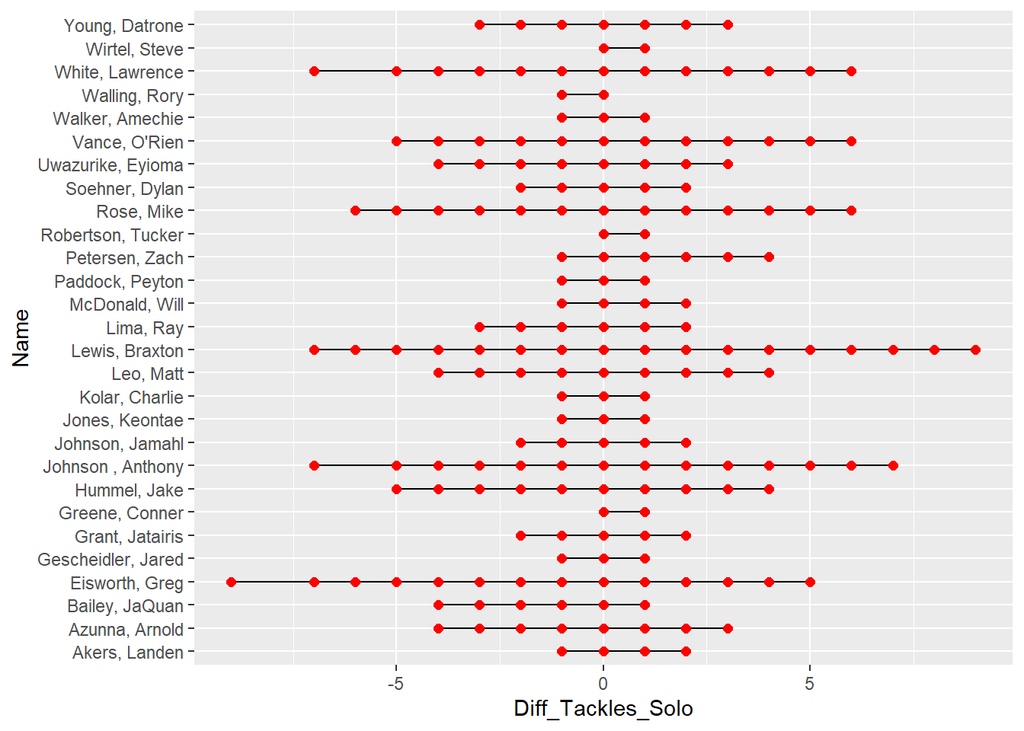

```r
ggplot(defComb, aes(x=Name, y=Diff_Tackles_Solo)) +
     geom_segment( aes(xend=Name, yend=0)) +
    geom_point( size=2, color="red") + coord_flip() + xlab("Name")
```

The two plyers on the defense roster that made improvements were Braxton Lewis and Anthony Johnson.

```r
offComb <- inner_join(offClean, offClean18, by ='Name') %>% mutate(Diff_Receiving_YDS = Receiving_YDS.x - Receiving_YDS.y) %>% select(Name, Diff_Receiving_YDS) %>% arrange(desc(Diff_Receiving_YDS))

offComb
```

```
## # A tibble: 1,223 x 2
##    Name             Diff_Receiving_YDS
##    <fct>                         <dbl>
##  1 Jones, Deshaunte                144
##  2 Milton, Tarique                 144
##  3 Milton, Tarique                 144
##  4 Milton, Tarique                 142
##  5 Milton, Tarique                 142
##  6 Milton, Tarique                 141
##  7 Jones, Deshaunte                140
##  8 Milton, Tarique                 139
##  9 Jones, Deshaunte                138
## 10 Milton, Tarique                 130
## # ... with 1,213 more rows
```

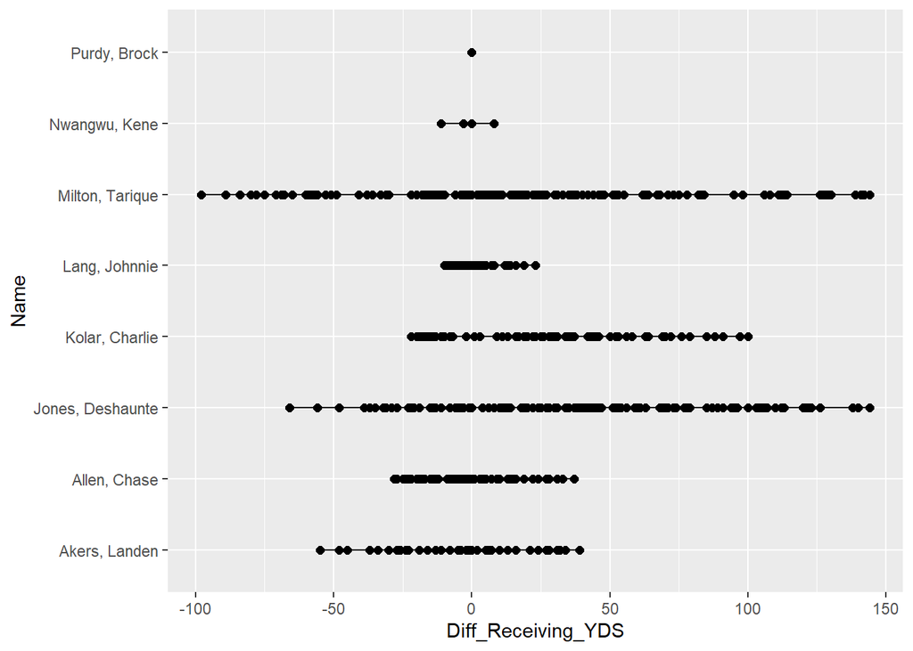

```r
ggplot(offComb, aes(x=Name, y=Diff_Receiving_YDS)) +
geom_segment(aes(xend = Name, yend = 0)) + geom_point( size = 2) + coord_flip() + xlab("Name")
```

For the offensive roster, Tarique Milton and Deshaunte Jones improved in performance when looking at the difference in receiving yards from 2019 and 2018. Brock Purdy has no change because he is the quarterback and we would have to observe his passing yards.